# FA1-Lansangan-Opres

### Operations Research

##### Formative Assessment 1 (Part 1)

## Item 1

1. The Primo Insurance Company is introducing two new product lines: special risk insurance and mortgages. The expected profit is 5 dollar per unit on special risk insurance and 2 dollar per unit on mortgages. Management wishes to establish sales quotas for the new product lines to maximize total expected profit. The work requirements are as follows:

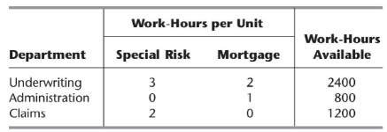

### Linear Model

#### Decision Variables

$x$ number of work-hours for special risk

$y$ number of work-hours for mortgage.

#### Objective Function

Maximize $P=5x+2y$

#### Constraints

$x,y \geq 0$

$3x + 2y \leq 2400$

$y \leq 800$

$2x \leq 1200$

### Solution via Graphical Method

The shade region is the feasible region.

To input the objective function $P=5x+2y$

[figure not shown]

#### Solution:

$(x,y) = (600,300)$

## Item 2

#### Model

Minimize $Z=40x_1 + 50x_2$

#### Constraints

$2x_1 + 3x_2 \geq 30$

$x_1 + x_2 \geq 12$

$2x_1 + x_2 \geq 20$

#### Solution view Graphical Method

The shaded region is the feasible region.

To input the objective function $Z=40x_1 + 50x_2$

[figure not shown]

#### Solution:

$(x_1, x_2)=(7.5,5)$

$Z=40x_1 + 50x_2 = 40(7.5)+50(5)=550$

#### If objective function is $Z=40x_1 + 70x_2$

[figure not shown]

$(x_1, x_2)=(15,0)$

$Z=40x_1 + 70x_2 = 40(15)+50(0)=600$

Both the solution and the value of Z will change. The Z increases so this isn't ideal considering we are trying to minimize the Z.

#### If third constraint is $2x_1 + x_2 \geq 15$

[figure not shown]

$(x_1, x_2)=(6,6)$

$Z=40x_1 + 50x_2 = 40(6)+50(6)=540$

So the Z will decrease compared to the original constraints, which is in fact ideal considering we are trying to minimize the Z.